# Agrégation de la base JOCAS”

Author

Claude Grasland

```r
library(knitr)
## Global options
options(max.print="80")
opts_chunk$set(echo=TRUE,
               cache=FALSE,
               prompt=FALSE,
               tidy=FALSE,
               comment=NA,
               message=FALSE,
               warning=FALSE,
               options(scipen=999))
opts_knit$set(width=75)

# Packages utilitaires
library(dplyr)
library(tidyr)
library(data.table)
# Packages graphiques
library(ggplot2)

#packages cartographiques
library(sf)
library(mapsf)
library(RColorBrewer)
```

Lorsque l’on travaille sur de très grands tableaux de données, il est indispensable d’effectuer des pré-traitements permettant de simplifier les données en fonction des objectifs de l’analyse.

Cela passe généralement par des fonctions d’**agrégation** qui produisent des tableaux plus petits issus de la base principale. ces tableaux agrégés permettront d’accélérer considérablement la production d’ensembles de tableaux, cartes ou graphiques à l’aide de **fonctions**.

## Préparation des données

### Chargement des fichiers

On commence par charger les données nettoyées au cours de l’étape précédente et les métadonnées associées.

```r
## Charge la base de données
base <- readRDS("jocas_france/data/jocas_france.RDS")

## Charge les fonds de carte
map_dep <-readRDS("jocas_france/data/map_dep.RDS")
map_reg <-readRDS("jocas_france/data/map_reg.RDS")

## Charge les code ROME
code_rome <- readRDS("jocas_france/data/code_rome.RDS")
```

### Jointure des données géographiques

On effectue ensuite une jointure des données géographiques mais sans la géométrie.

```r
# Elimine la géométrie
code_geo <- st_drop_geometry(map_dep)

# Effectue la jointure par le code départemental
base <- left_join(base, code_geo)
```

### Jointure des codes ROME

On effectue la même opération pour les codes ROME aux trois niveaux d’agrégation :

```r
# Effectue la jointure par le code départemental
base <- left_join(base, code_rome)
```

### Bilan des varirables disponibles

On dispose désormais d’un tableau enrichi comportant 14 variables

```r
names(base)
```

```
 [1] "date"         "dep"          "job"          "typ"          "sal"
 [6] "dur"          "dep_nom"      "reg"          "reg_nom"      "job_name"
[11] "dom"          "dom_name"     "big_dom"      "big_dom_name"
```

## Création de cubes

On souhaite analyser la distribution des emplois par mois (WHEN), par régions (WHERE) et par grand domaines de métier (WHAT) afin d’avoir une vision simplifiée de la distribution des offres d’emploi On va donc construire un tableau de contingence à trois dimensions dont les cellules correspondront à des comptages de nombre d’annonces.

### Cube1 : mois x régions x grands domaines

```r
cube1 <- base %>%  mutate(when = cut(date, breaks="month"),
                          when_name =substr(as.character(when),6,7),
                          where = reg,
                          where_name = reg_nom,
                          what = big_dom,
                          what_name = big_dom_name) %>%
                   na.omit() %>%
                   group_by(when, where, what, when_name, where_name, what_name) %>%
                   count() %>%
                   as.data.frame()


head(cube1)
```

```
        when where what when_name    where_name
1 2020-01-01    11    A        01 Île-de-France
2 2020-01-01    11    B        01 Île-de-France
3 2020-01-01    11    C        01 Île-de-France
4 2020-01-01    11    D        01 Île-de-France
5 2020-01-01    11    E        01 Île-de-France
6 2020-01-01    11    F        01 Île-de-France
                                                                   what_name
1 Agriculture et Pêche, Espaces naturels et Espaces verts, Soins aux animaux
2                                         Arts et Façonnage d'ouvrages d'art
3                                              Banque, Assurance, Immobilier
4                                     Commerce, Vente et Grande distribution
5                                         Communication, Média et Multimédia
6                                  Construction, Bâtiment et Travaux publics
    n
1  67
2  19
3 162
4 860
5  70
6 644
```

Le cube comporte **2140** lignes seulement car tous les cas possibles ne sont pas présents. Le fichier initial en comportait **3.7 millions**. C’est donc un fichier très léger et beaucoup plus facile à utiliser dans une application web. Il offre pourtant un nombre très élevé de possibilités.

### Cube2 : semaines x départements x domaines

On refait un cube plus précis en croisant les semaines, les domaines et les départements

```r
cube2 <- base %>%  mutate(when = cut(date, breaks="weeks"),
                          when_name =substr(as.character(when),6,7),
                          where = dep,
                          where_name = dep_nom,
                          what = dom,
                          what_name = dom_name) %>%
                   na.omit() %>%
                   group_by(when, where, what, when_name, where_name, what_name) %>%
                   count() %>%
                   as.data.frame()


head(cube2)
```

```
        when where what when_name where_name
1 2019-12-30    01  A14        12        Ain
2 2019-12-30    01  B18        12        Ain
3 2019-12-30    01  D12        12        Ain
4 2019-12-30    01  D14        12        Ain
5 2019-12-30    01  D15        12        Ain
6 2019-12-30    01  E11        12        Ain
                                              what_name n
1                                            Production 1
2                                        Tissu et cuirs 2
3 Commerce non alimentaire et de prestations de confort 1
4                                        Force de vente 3
5                                   Grande distribution 1
6                              Edition et communication 1
```

## Fonctions élémentaires

On va créer des fonctions permettant d’explorer une dimension à la fois

### Analyse temporelle (when)

Nous allons créer deux fonctions `tab_when` et `fig_when` pour faire soit un tableau, soit un graphique à partir d’un cube

```r
tab_when <- function(cube = cube) {

  tab <- cube %>%
           group_by(when, when_name) %>%
           summarise(n=sum(n)) %>%
           mutate(when=as.Date(when)) %>%
           as.data.frame()

return(tab)
}


fig_when <- function(cube = cube) {

  tab <- tab_when(cube)

   fig <- ggplot(tab) +
     aes(x=when, y = n) +
     geom_point()+
     geom_line() +
     geom_smooth(method="lm")

  return(fig)}
```

On applique nos fonction sur le cube1

```r
tab_when(cube1)
```

```
         when when_name     n
1  2020-01-01        01 74859
2  2020-02-01        02 69990
3  2020-03-01        03 46793
4  2020-04-01        04 21674
5  2020-05-01        05 36187
6  2020-06-01        06 65577
7  2020-07-01        07 63812
8  2020-08-01        08 54275
9  2020-09-01        09 72949
10 2020-10-01        10 55036
11 2020-11-01        11 45234
12 2020-12-01        12 48647
```

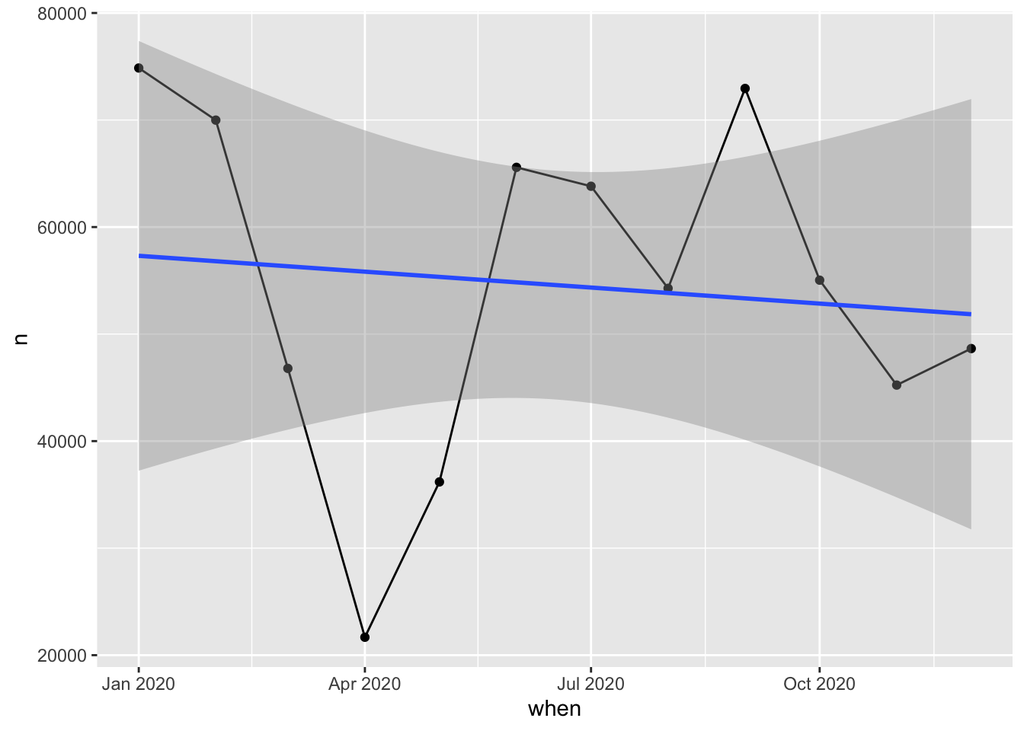

```r
fig_when(cube1)
```

On vérifie ensuite qu’elle marche sur le cube2

```r
tab_when(cube2)
```

```
         when when_name     n
1  2019-12-30        12  4983
2  2020-01-06        01 18419
3  2020-01-13        01 19080
4  2020-01-20        01 18709
5  2020-01-27        01 14052
6  2020-02-03        02 16932
7  2020-02-10        02 17053
8  2020-02-17        02 18633
9  2020-02-24        02 17120
10 2020-03-02        03 17422
11 2020-03-09        03 17778
12 2020-03-16        03  4372
13 2020-03-23        03  5084
14 2020-03-30        03  5041
15 2020-04-06        04  5279
16 2020-04-13        04  4273
17 2020-04-20        04  5651
18 2020-04-27        04  3671
19 2020-05-04        05  5794
20 2020-05-11        05 10438
21 2020-05-18        05  7625
22 2020-05-25        05 12094
23 2020-06-01        06 11772
24 2020-06-08        06 16066
25 2020-06-15        06 14570
26 2020-06-22        06 16707
 [ reached 'max' / getOption("max.print") -- omitted 27 rows ]
```

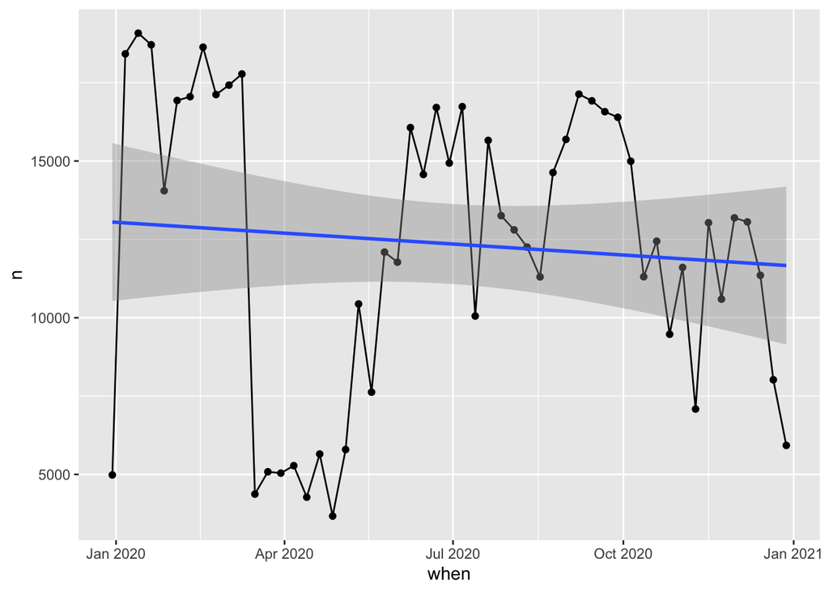

```r
fig_when(cube2)
```

### Analyse catégorielle (what)

Nous allons ensuite créer deux fonctions `tab_what()` et `fig_what()` qui permettent de visualiser le poids des différents types d’emploi.

```r
tab_what <- function(cube = cube) {

  tab <- cube %>%
           group_by(what, what_name) %>%
           summarise(n=sum(n)) %>%
           arrange(-n) %>%
           as.data.frame()

   return(tab)
}


fig_what <- function(cube = cube) {

  tab <- tab_what(cube)

   fig <- ggplot(tab) +
     aes(x=what, y = n) +
     geom_col()

   return(fig)
}
```

On teste nos fonctions sur le cube1

```r
tab_what(cube1)
```

```
   what
1     K
2     F
3     H
4     D
5     G
6     M
7     N
8     I
9     J
10    A
11    C
12    E
13    B
14    L
```

[output cut: 30 more lines]

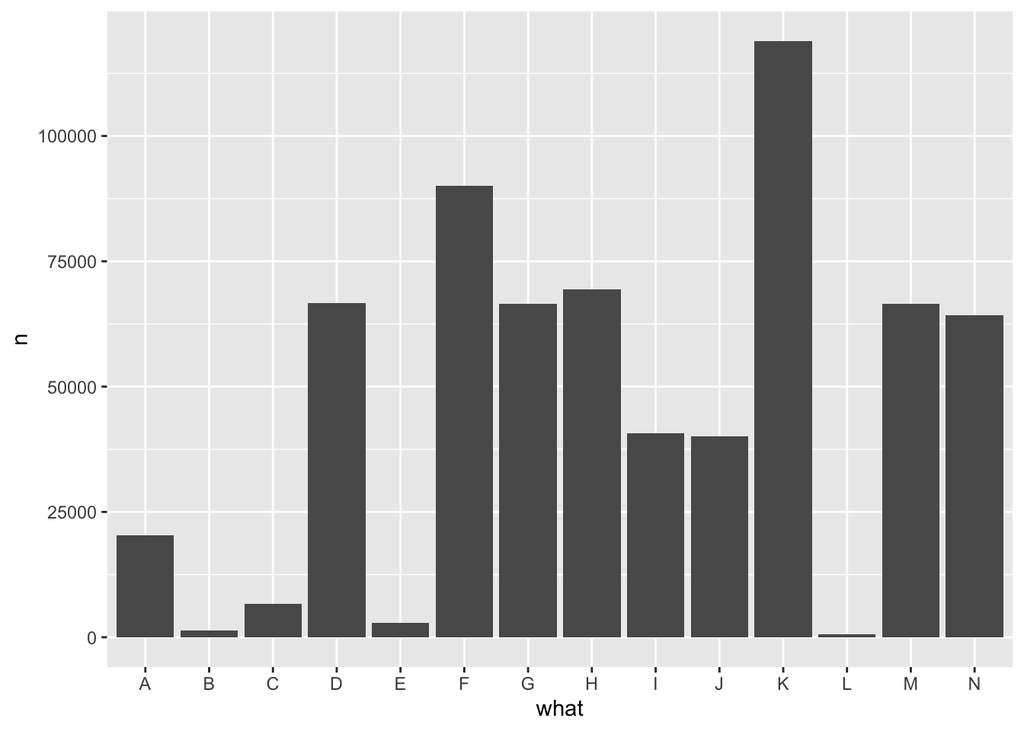

```r
fig_what(cube1)
```

et sur le cube2 :

```r
tab_what(cube2)
```

```
   what                                             what_name     n
1   F16                                         Second oeuvre 44507
2   N11   Magasinage, manutention des charges et déménagement 37162
3   K13                             Aide à la vie quotidienne 33043
4   K21                        Formation initiale et continue 28506
5   G16                                  Production culinaire 28382
6   F17                                Travaux et gros oeuvre 26867
7   M16                             Secrétariat et assistance 25981
8   J15                                    Soins paramédicaux 24734
9   K22                     Nettoyage et propreté industriels 22652
10  N41            Personnel de conduite du transport routier 21778
11  H29            Mécanique, travail des métaux et outillage 21129
12  D12 Commerce non alimentaire et de prestations de confort 18323
13  I13     Equipements de production, équipements collectifs 17753
14  D15                                   Grande distribution 17364
15  D14                                        Force de vente 16711
16  M12                               Comptabilité et gestion 15580
17  G18                                               Service 14616
18  D11             Commerce alimentaire et métiers de bouche 13754
19  K12   Action sociale, socio-éducative et socio-culturelle 12492
20  J13                      Professionnels médico-techniques 12388
21  G12                      Animation d'activités de loisirs 12073
22  M14                                Organisation et études 11609
23  A14                                            Production 11389
24  I16                           Véhicules, engins, aéronefs 10514
25  H33                        Préparation et conditionnement  9429
26  I12                                   Entretien technique  8418
 [ reached 'max' / getOption("max.print") -- omitted 83 rows ]
```

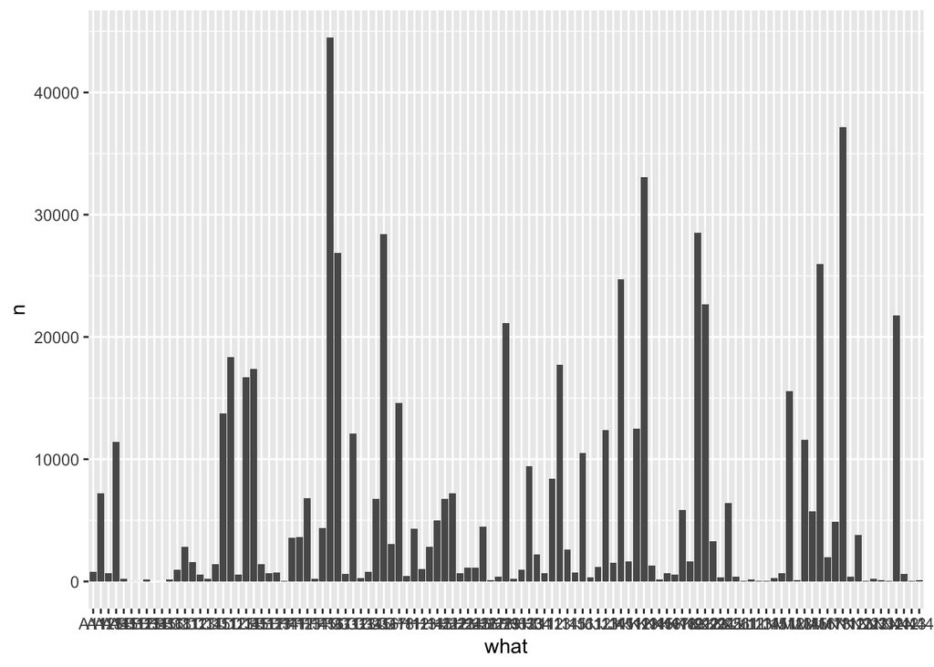

```r
fig_what(cube2)
```

### Analyse spatiale (where)

Nous allons maintenant créer des fonctions de cartographie pour visualiser nos données par régions ou département.

#### Analyse par régions

```r
tab_where_reg <- function(cube = cube) {

  tab <- cube %>%
           group_by(where, where_name) %>%
           summarise(n=sum(n)) %>%
           rename(reg=where) %>%
           as.data.frame()

   return(tab)
}

fig_where_reg <- function(cube = cube){

  tab <- tab_where_reg(cube)

  mapdon<-left_join(map_reg,tab)

  mf_map(mapdon,
         type="base",
         col="lightyellow")
  mf_map(mapdon,
         type="prop",
         var="n",
         inches=0.1)
  mf_layout(title = "Offres d'emplois par région",
            frame=T,
            credits = "Source : base JOCAS, 2020")
}


tab_where_reg(cube1)
```

```
   reg                 where_name     n
1   11              Île-de-France 56640
2   24        Centre-Val de Loire 25020
3   27    Bourgogne-Franche-Comté 29519
4   28                  Normandie 31369
5   32            Hauts-de-France 46949
6   44                  Grand Est 51212
7   52           Pays de la Loire 50315
8   53                   Bretagne 43153
9   75         Nouvelle-Aquitaine 80844
10  76                  Occitanie 73152
11  84       Auvergne-Rhône-Alpes 94352
12  93 Provence-Alpes-Côte d'Azur 67350
13  94                      Corse  5158
```

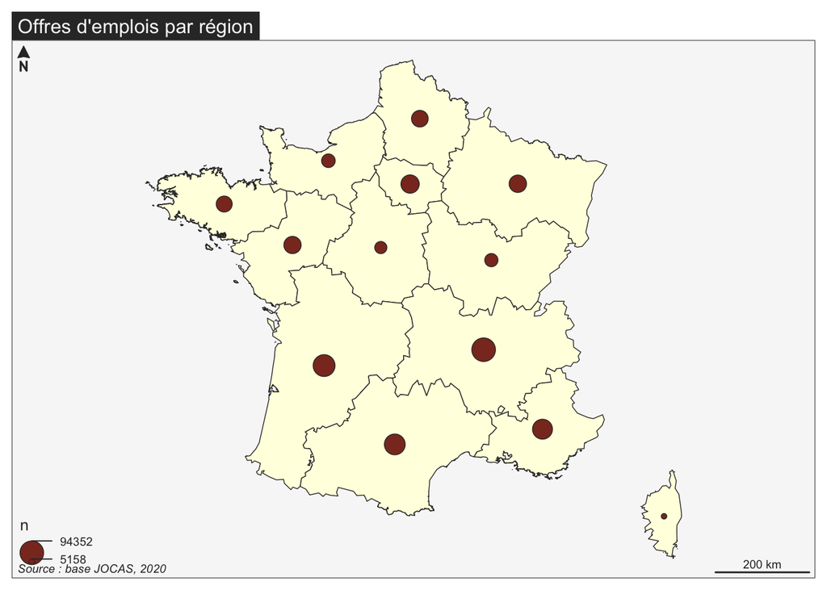

```r
fig_where_reg(cube1)
```

#### Analyse par départements

```r
tab_where_dep <- function(cube = cube) {

  tab <- cube %>%
           group_by(where, where_name) %>%
           summarise(n=sum(n)) %>%
           rename(dep=where) %>%
           as.data.frame()

   return(tab)
}

fig_where_dep <- function(cube = cube){

  tab <- tab_where_dep(cube)

  mapdon<-left_join(map_dep,tab)

  mf_map(mapdon,
         type="base",
         col="lightyellow")
  mf_map(mapdon,
         type="prop",
         var="n",
         inches=0.1)
  mf_layout(title = "Offres d'emplois par département",
            frame=T,
            credits = "Source : base JOCAS, 2020")
}


tab_where_dep(cube2)
```

```
   dep              where_name     n
1   01                     Ain  6700
2   02                   Aisne  4586
3   03                  Allier  3050
4   04 Alpes-de-Haute-Provence  2141
5   05            Hautes-Alpes  3045
6   06         Alpes-Maritimes 10876
7   07                 Ardèche  4292
8   08                Ardennes  2454
9   09                  Ariège  2386
10  10                    Aube  3302
11  11                    Aude  5278
12  12                 Aveyron  3319
13  13        Bouches-du-Rhône 25261
14  14                Calvados  8274
15  15                  Cantal  1112
16  16                Charente  4429
17  17       Charente-Maritime 11166
18  18                    Cher  2684
19  19                 Corrèze  2303
20  21               Côte-d'Or  6779
21  22           Côtes-d'Armor  7781
22  23                  Creuse  1289
23  24                Dordogne  4077
24  25                   Doubs  5041
25  26                   Drôme  7327
26  27                    Eure  5052
 [ reached 'max' / getOption("max.print") -- omitted 70 rows ]
```

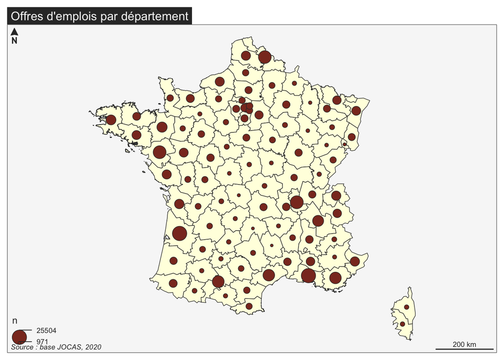

```r
fig_where_dep(cube2)
```

## Fonctions complexes

On peut créer des fonctions plus complexe croisant plusieurs dimensions.

### Exemple 1 : comparaison des évolutions temporelles de départements

Supposons que l’on veuille comparer l’évolution des offres d’emploi dans plusieurs départements

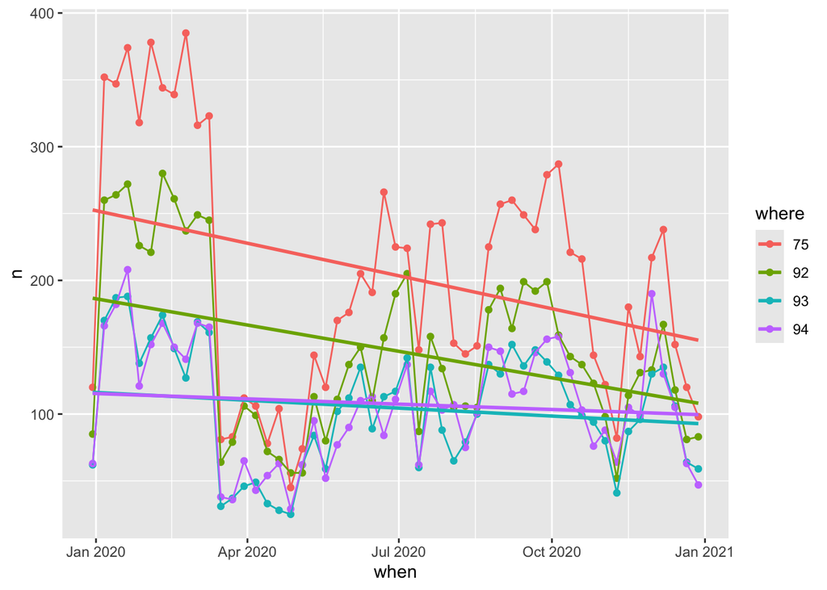

```r
tab_when_where<-function(cube=cube2, locs=c("75","92","93","94")){
  tab<-cube %>% filter(where %in% locs ) %>%
              group_by(when, where) %>%
              summarise(n=sum(n)) %>%
              mutate(when=as.Date(when)) %>%
              as.data.frame()
  return(tab)
}

fig_when_where <- function(cube=cube2,locs=c("75","92","93","94")) {

  tab<-tab_when_where(cube,locs)

     fig <- ggplot(tab) +
     aes(x=when, y = n, col=where) +
     geom_point()+
     geom_line() +
     geom_smooth(method="lm",fill = NA)

     return(fig)

}

fig_when_where(cube2, c("75","92","93","94"))
```